# assignment #4

20141831 박석환

2020 5 8

### 1. 다음의 순서로 data preprocessing을 진행하자.

- 항공기 출발시각(deptime)이 6시 이전이거나 22시 이후인 데이터는 빈도 수가 매우 적으므로 데이 터셋에서 제외시킨다.
- 수치값으로 표현되어 있는 출발시각을 6시부터 22시까지 각 시간대를 나타내는 범주형 변수로 변환 한다 (Hint: 원 데이터를 100으로 나눈 후 정수값으로 내림. 그 후 factor로 변환)
- 수치값으로 표현되어 있는 dayweek와 weather 변수를 factor로 변환한다.
- factor로 표현되어 있는 delay 변수가 가지는 level의 순서를 “ontime”, “delayed” 순으로 변환한 다 (logistic regression 수행 시에 연착하는 경우를 로 만들기 위해서).

**항공기 출발시각(deptime)이 6시 이전이거나 22시 이후인 데이터는 빈도 수가 매우 적으므로 데이 터셋에서 제외시킨다.**

```r
record <- read.csv("FlightRecords.csv")
record <- record[-c(1,5,6,7,11,12)]
record <- subset(record, deptime >= 600 & deptime < 2200)
head(record)
```

```
##   carrier deptime dest origin weather dayweek  delay
## 1      OH    1455  JFK    BWI       0       4 ontime
## 2      DH    1640  JFK    DCA       0       4 ontime
## 3      DH    1245  LGA    IAD       0       4 ontime
## 4      DH    1709  LGA    IAD       0       4 ontime
## 5      DH    1035  LGA    IAD       0       4 ontime
## 6      DH     839  JFK    IAD       0       4 ontime
```

**수치값으로 표현되어 있는 출발시각을 6시부터 22시까지 각 시간대를 나타내는 범주형 변수로 변환 한다 (Hint: 원 데이터를 100으로 나눈 후 정수값으로 내림. 그 후 factor로 변환)**

```r
record$deptime <- record$deptime%/%100
record$deptime <- as.factor(record$deptime)
head(record$deptime)
```

```
## [1] 14 16 12 17 10 8
## Levels: 6 7 8 9 10 11 12 13 14 15 16 17 18 19 20 21
```

**수치값으로 표현되어 있는 dayweek와 weather 변수를 factor로 변환한다.**

```r
record$dayweek <- as.factor(record$dayweek)
record$weather <- as.factor(record$weather)
str(record$dayweek)
```

```
##  Factor w/ 7 levels "1","2","3","4",..: 4 4 4 4 4 4 4 4 4 4 ...
```

```r
str(record$weather)
```

```
##  Factor w/ 2 levels "0","1": 1 1 1 1 1 1 1 1 1 1 ...
```

**factor로 표현되어 있는 delay 변수가 가지는 level의 순서를 “ontime”, “delayed” 순으로 변환한 다 (logistic regression 수행 시에 연착하는 경우를 로 만들기 위해서).**

```r
record$delay <- factor(record$delay, levels = c("ontime","delayed"))
str(record$delay)
```

```
##  Factor w/ 2 levels "ontime","delayed": 1 1 1 1 1 1 1 1 1 1 ...
```

### 2. 요일 별 연착비율, 출발 시간대 별 연착 비율, 출발 공항 별 연착비율, 도착 공항 별 연착 비율, 항공사 별 연착 비율, 날씨 별 연착 비율을 각각 그래프로 시각화해보자. 어떤 특성을 관찰할 수 있는가?

```r
library(ggplot2)
```

ggplot2 패키지를 불러온다

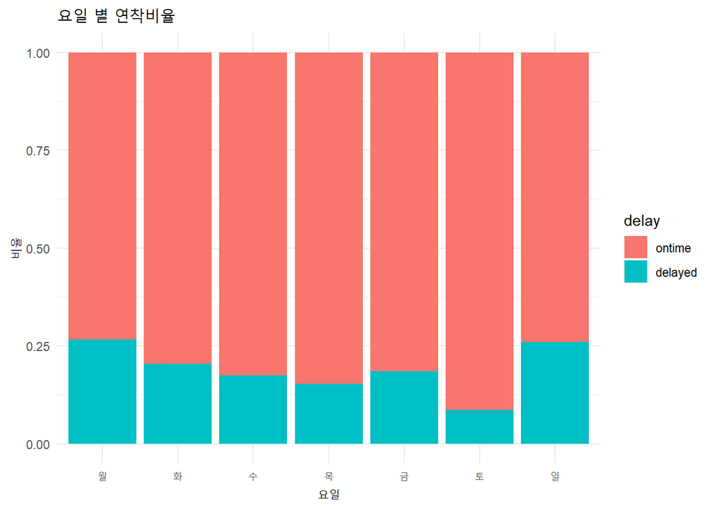

```r
ggplot(record, aes(dayweek, fill=delay))+
  geom_bar(position='fill') +
  theme_minimal() + theme(text = element_text(size = 10)) +
  labs(title = "요일 별 연착비율", x = "요일", y = "비율" ) +
  scale_x_discrete(labels = c("월","화","수","목","금","토","일")) + theme_minimal()
```

**월요일**과 **일요일**의 연착률이 높고 **토요일**의 연착률이 낮은 것을 확일할 수 있다.

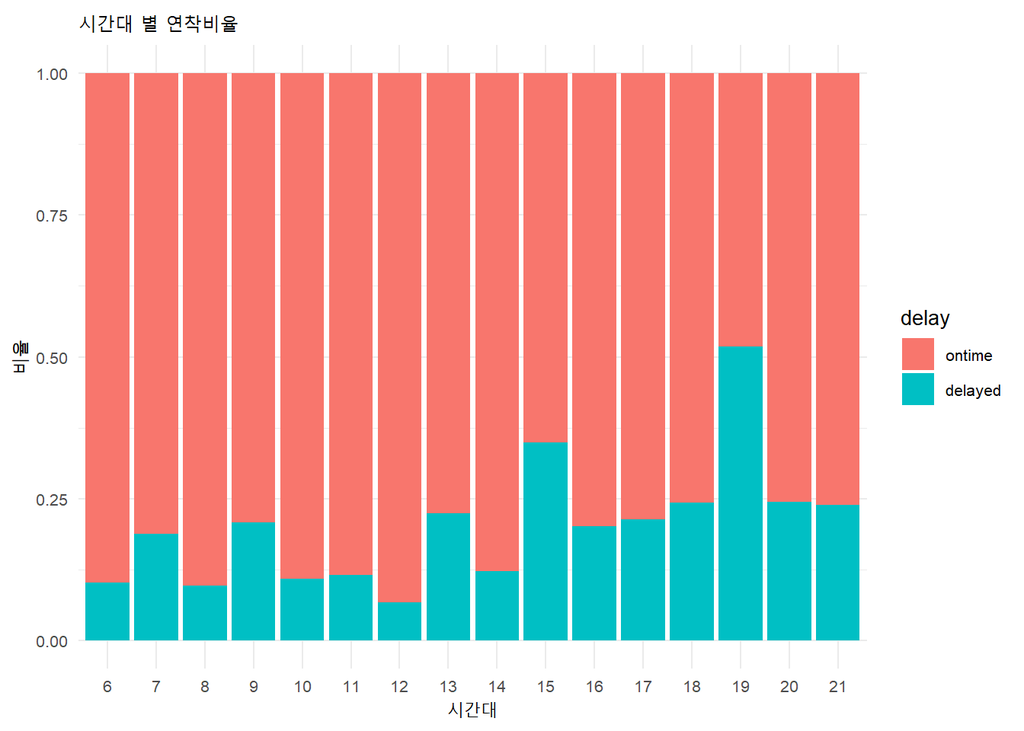

```r
ggplot(record, aes(deptime, fill=delay))+
  geom_bar(position='fill') +
  theme_minimal() + theme(text = element_text(size = 10)) +
  labs(title = "시간대 별 연착비율", x = "시간대", y = "비율" )
```

출발시간이 **19시** 인 경우 연착률이 제일 높고, **12시**의 연착률이 가장 확일할 수 있다.

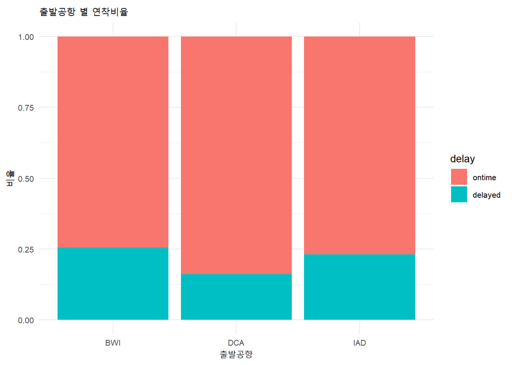

```r
ggplot(record, aes(origin, fill=delay))+
  geom_bar(position='fill') +
  theme_minimal() + theme(text = element_text(size = 10)) +
  labs(title = "출발공항 별 연착비율", x = "출발공항", y = "비율" )
```

**Baltimore_Washington**의 역착률이 가장 높고 **Reagon Nation**의 연착률이 가장 낮은 것을 확인할 수 있다.

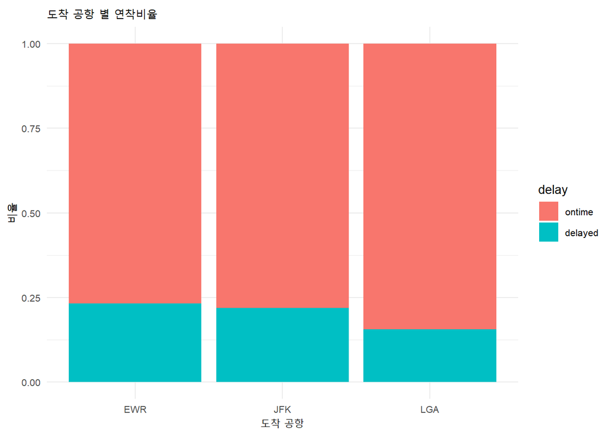

```r
ggplot(record, aes(dest, fill=delay))+
  geom_bar(position='fill') +
  theme_minimal() + theme(text = element_text(size = 10)) +
  labs(title = "도착 공항 별 연착비율", x = "도착 공항", y = "비율" )
```

나머지 두 공항에 비해 **LaGuardia** 공항의 연착률이 낮은 것을 확인할 수 있다.

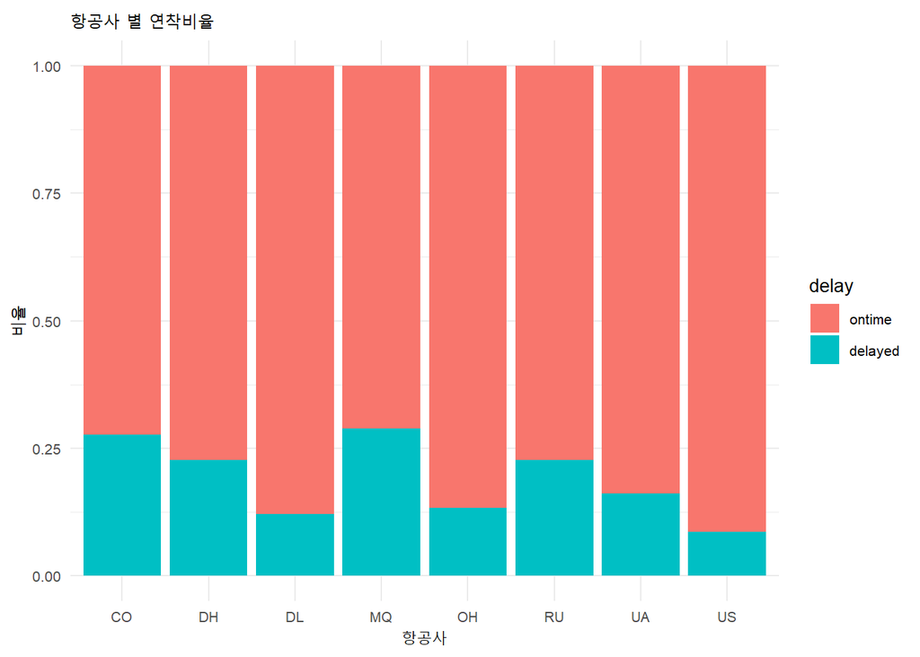

```r
ggplot(record, aes(carrier, fill=delay))+
  geom_bar(position='fill') +
  theme_minimal() + theme(text = element_text(size = 10)) +
  labs(title = "항공사 별 연착비율", x = "항공사", y = "비율" )
```

항공사 **American Eagle**의 연착률이 가장 높고 **USAirways**의 연착률이 가장 낮은 것을 확인할 수 있다.

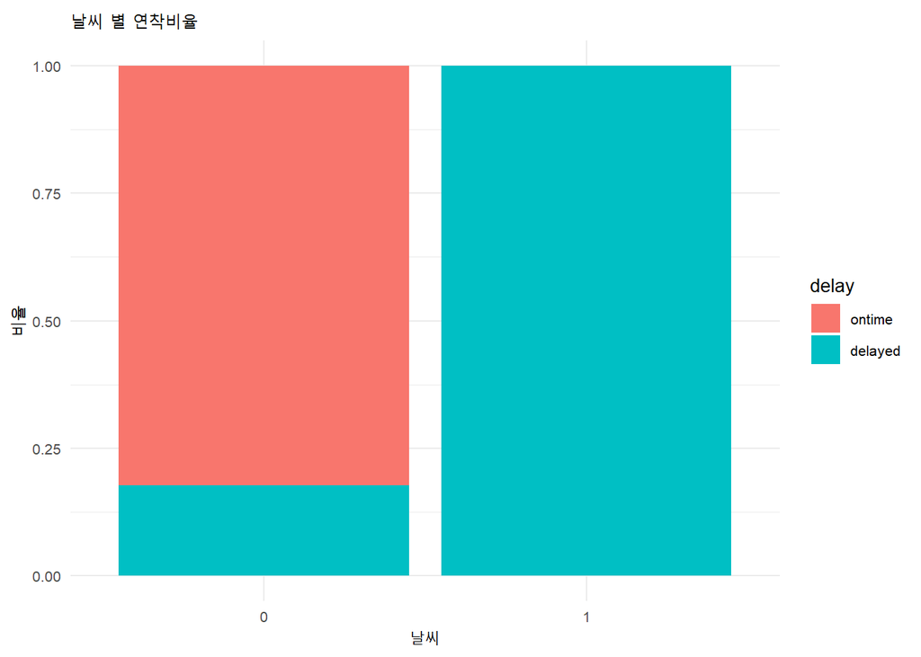

```r
ggplot(record, aes(weather, fill=delay))+
  geom_bar(position='fill') +
  theme_minimal() + theme(text = element_text(size = 10)) +
  labs(title = "날씨 별 연착비율", x = "날씨", y = "비율" )
```

날씨가 **BAD**인 경우 100%의 연착률을 기록하는 것을 확인할 수 있다.

### 3. 7개의 모든 변수들 간의 상관관계를 시각화해보자. 어떤 특성을 관찰할 수 있는가?

```r
library(psych)
```

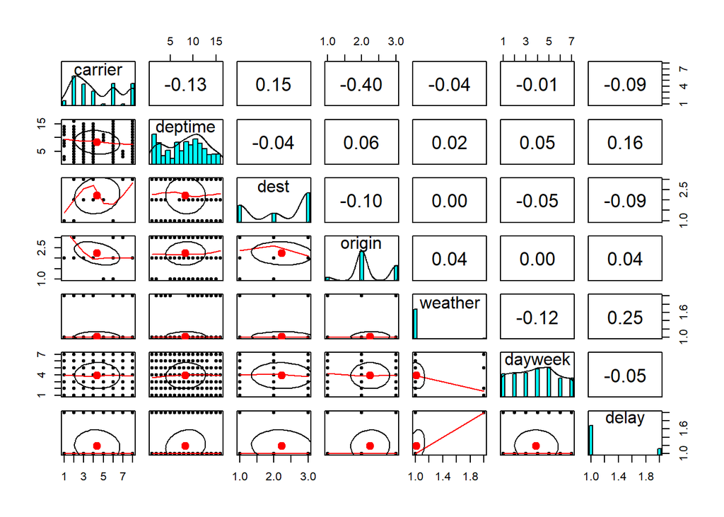

```r
pairs.panels(record)
```

7개 변수들 사이의 강한 상관관계를 가진 관계는 없는 것을 확인할 수 있다. 즉 각 feature들 사이의 multicollinearity 약하다는 것을 의미한다.

### 4. 데이터셋을 70:30 비율로 training set과 test set으로 분할하자. 이때 stratiﬁed sampling을 활용하여 두 set에서 delay 변수의 분포가 크게 차이가 없도록 분할하자.

```r
library(rsample)
set.seed(123)
split <- initial_split(record, prop = 0.7, strata = "delay")
data_train <- training(split)
data_test <- testing(split)
```

initial_split() 함수를 이용하여 train set과 test set으로 stratified sampling을 진행한다.

### 5. 데이터시각화로부터 weather 변수가 “Bad” 인 경우에는 항상 항공기가 연착되는 것을 관찰할 수 있다. 따라 서 weather가 Bad이면 항공기가 연착되고, weather가 OK일 경우 항공기가 연착되지 않는 것으로 예측하 는 단순한 모델을 baseline model이라 하자. Test set에 대해 baseline model을 적용했을 때 confusion matrix를 계산해 보세요.

```r
library(caret)
pred_base = factor(sign(data_test$weather == "Bad"), levels = c(0,1), labels=c("ontime","delayed"))

confusionMatrix(pred_base, data_test$delay, positive = "delayed")
```

```
## Confusion Matrix and Statistics
##
##           Reference
## Prediction ontime delayed
##    ontime     525     122
##    delayed      0       0
##
##                Accuracy : 0.8114
##                  95% CI : (0.7791, 0.8409)
##     No Information Rate : 0.8114
##     P-Value [Acc > NIR] : 0.5242
##
##                   Kappa : 0
##
##  Mcnemar's Test P-Value : <2e-16
##
##             Sensitivity : 0.0000
##             Specificity : 1.0000
##          Pos Pred Value :    NaN
##          Neg Pred Value : 0.8114
##              Prevalence : 0.1886
##          Detection Rate : 0.0000
##    Detection Prevalence : 0.0000
##       Balanced Accuracy : 0.5000
##
##        'Positive' Class : delayed
##
```

baseline model은 test set에 대하여 **81.14%**의 accuracy를 가진다. 날씨가 **BAD**인 경우에는 delay라 예측하였기 때문에 specificity는 1이 나왔다.

### 6. Training set을 대상으로, 연착여부(delay)를 나머지 모든 변수를 사용하여 예측하기 위한 logistic regression model을 수립해보자.

### 6.1 변수 deptime19의 regression coefﬁcient에 대한 추정값은 얼마인가? 이 추정값을 바탕으로 출 발시각이 19시대인 항공기에 대해서 어떠한 해석을 할 수 있는가? (Hint: 범주형 변수 deptime을 model에 추가할 때 deptime6을 제외한 deptime7 ~ deptime21의 dummy 변수가 만들어진다.)

```r
set.seed(123)
model1 = glm(delay ~ ., data = data_train, family="binomial")
summary(model1)
```

```
##
## Call:
## glm(formula = delay ~ ., family = "binomial", data = data_train)
##
## Deviance Residuals:
##     Min       1Q   Median       3Q      Max
## -1.7062  -0.6330  -0.4682  -0.2536   2.7698
##
## Coefficients:
##              Estimate Std. Error z value Pr(>|z|)
## (Intercept)  -0.22195    0.61263  -0.362 0.717130
## carrierDH    -0.92739    0.55339  -1.676 0.093769 .
## carrierDL    -1.47989    0.51558  -2.870 0.004101 **
## carrierMQ    -0.20680    0.48784  -0.424 0.671631
## carrierOH    -1.42050    0.85996  -1.652 0.098570 .
## carrierRU    -0.77349    0.42382  -1.825 0.067999 .
## carrierUA    -1.77673    1.02612  -1.732 0.083360 .
## carrierUS    -1.81208    0.52262  -3.467 0.000526 ***
## deptime7      0.30868    0.49279   0.626 0.531057
## deptime8      0.01138    0.44921   0.025 0.979790
## deptime9      1.49375    0.50407   2.963 0.003043 **
## deptime10    -0.17018    0.49551  -0.343 0.731259
## deptime11    -0.02284    0.81193  -0.028 0.977563
## deptime12    -0.46717    0.45974  -1.016 0.309555
## deptime13     1.09505    0.40969   2.673 0.007520 **
## deptime14    -0.08903    0.42308  -0.210 0.833335
## deptime15     1.68475    0.38342   4.394 1.11e-05 ***
## deptime16     0.88760    0.38638   2.297 0.021607 *
## deptime17     0.87711    0.37890   2.315 0.020621 *
## deptime18     1.14860    0.41212   2.787 0.005319 **
## deptime19     2.57044    0.44809   5.736 9.67e-09 ***
## deptime20     1.38581    0.46820   2.960 0.003078 **
## deptime21     0.71707    0.44908   1.597 0.110322
## destJFK      -0.15592    0.32761  -0.476 0.634133
## destLGA       0.28194    0.33636   0.838 0.401917
## originDCA    -1.23374    0.39269  -3.142 0.001679 **
## originIAD    -0.32671    0.37791  -0.865 0.387303
## weather1     17.56718  500.86204   0.035 0.972021
## dayweek2     -0.34612    0.26596  -1.301 0.193125
## dayweek3     -0.49452    0.26130  -1.893 0.058421 .
## dayweek4     -0.53836    0.25922  -2.077 0.037817 *
## dayweek5     -0.24197    0.24498  -0.988 0.323307
## dayweek6     -1.17170    0.33498  -3.498 0.000469 ***
## dayweek7     -0.11203    0.27348  -0.410 0.682068
## ---
## Signif. codes:  0 '***' 0.001 '**' 0.01 '*' 0.05 '.' 0.1 ' ' 1
##
## (Dispersion parameter for binomial family taken to be 1)
##
##     Null deviance: 1469.5  on 1511  degrees of freedom
## Residual deviance: 1216.4  on 1478  degrees of freedom
## AIC: 1284.4
##
## Number of Fisher Scoring iterations: 15
```

```r
coef(model1)
```

```
## (Intercept)   carrierDH   carrierDL   carrierMQ   carrierOH   carrierRU
## -0.22195255 -0.92738901 -1.47988539 -0.20680132 -1.42049898 -0.77348518
##   carrierUA   carrierUS    deptime7    deptime8    deptime9   deptime10
## -1.77673347 -1.81207645  0.30868067  0.01137961  1.49375361 -0.17018338
##   deptime11   deptime12   deptime13   deptime14   deptime15   deptime16
## -0.02283544 -0.46717126  1.09505096 -0.08902660  1.68475055  0.88760229
##   deptime17   deptime18   deptime19   deptime20   deptime21     destJFK
##  0.87710743  1.14860147  2.57044231  1.38581017  0.71707126 -0.15591744
##     destLGA   originDCA   originIAD    weather1    dayweek2    dayweek3
##  0.28193635 -1.23374401 -0.32671006 17.56718087 -0.34612100 -0.49451572
##    dayweek4    dayweek5    dayweek6    dayweek7
## -0.53836256 -0.24196668 -1.17170278 -0.11203003
```

변수 **deptime19**의 coef 추정값은 **2.57044231**이다. 즉, deptime은 양의 상관관계를 갖고 있다고 해석할 수 있다.

### 6.2 날씨에 문제가 없는 금요일 15시에 IAD에서 출발하여 JFK로 도착한 Delta 항공기가 연착될 확률은 얼마로 예측되는가?

```r
new_data = data.frame(weather = "0", dayweek = "5", deptime = "15", origin= "IAD", dest="JFK", carrier = "DL")
set.seed(123)
test_prob <- predict(model1, newdata = new_data, type = "response")
test_prob
```

```
##         1
## 0.3226365
```

주어진 조건에 맞는 항공기가 연착될 확률은 **32.26%** 이다.

### 6.3 Threshold 에 대해서 각각 test set에 대한 confusion matrix를 계산해 보 자. 어떠한 경향을 관찰할 수 있는가?

```r
set.seed(123)
prob_test <- predict(model1, data_test, type = "response")
```

```r
pred_2 = rep("ontime", 647)
pred_2[prob_test > 0.2] = "delayed"
cm2<-confusionMatrix(factor(pred_2, levels = c("ontime","delayed")), data_test$delay, positive = "delayed")
cm2
```

```
## Confusion Matrix and Statistics
##
##           Reference
## Prediction ontime delayed
##    ontime     382      45
##    delayed    143      77
##
##                Accuracy : 0.7094
##                  95% CI : (0.6728, 0.7442)
##     No Information Rate : 0.8114
##     P-Value [Acc > NIR] : 1
##
##                   Kappa : 0.2742
##
##  Mcnemar's Test P-Value : 1.5e-12
##
##             Sensitivity : 0.6311
##             Specificity : 0.7276
##          Pos Pred Value : 0.3500
##          Neg Pred Value : 0.8946
##              Prevalence : 0.1886
##          Detection Rate : 0.1190
##    Detection Prevalence : 0.3400
##       Balanced Accuracy : 0.6794
##
##        'Positive' Class : delayed
##
```

```r
pred_3 = rep("ontime", 647)
pred_3[prob_test > 0.3] = "delayed"
cm3<-confusionMatrix(factor(pred_3, levels = c("ontime","delayed")), data_test$delay, positive = "delayed")
cm3
```

```
## Confusion Matrix and Statistics
##
##           Reference
## Prediction ontime delayed
##    ontime     452      65
##    delayed     73      57
##
##                Accuracy : 0.7867
##                  95% CI : (0.7531, 0.8177)
##     No Information Rate : 0.8114
##     P-Value [Acc > NIR] : 0.9496
##
##                   Kappa : 0.3201
##
##  Mcnemar's Test P-Value : 0.5513
##
##             Sensitivity : 0.4672
##             Specificity : 0.8610
##          Pos Pred Value : 0.4385
##          Neg Pred Value : 0.8743
##              Prevalence : 0.1886
##          Detection Rate : 0.0881
##    Detection Prevalence : 0.2009
##       Balanced Accuracy : 0.6641
##
##        'Positive' Class : delayed
##
```

```r
pred_5 = rep("ontime", 647)
pred_5[prob_test > 0.5] = "delayed"
cm5<-confusionMatrix(factor(pred_5, levels = c("ontime","delayed")), data_test$delay, positive = "delayed")
cm5
```

```
## Confusion Matrix and Statistics
##
##           Reference
## Prediction ontime delayed
##    ontime     519      92
##    delayed      6      30
##
##                Accuracy : 0.8485
##                  95% CI : (0.8186, 0.8753)
##     No Information Rate : 0.8114
##     P-Value [Acc > NIR] : 0.007869
##
##                   Kappa : 0.3214
##
##  Mcnemar's Test P-Value : < 2.2e-16
##
##             Sensitivity : 0.24590
##             Specificity : 0.98857
##          Pos Pred Value : 0.83333
##          Neg Pred Value : 0.84943
##              Prevalence : 0.18856
##          Detection Rate : 0.04637
##    Detection Prevalence : 0.05564
##       Balanced Accuracy : 0.61724
##
##        'Positive' Class : delayed
##
```

```r
pred_7 = rep("ontime", 647)
pred_7[prob_test > 0.7] = "delayed"
cm7<-confusionMatrix(factor(pred_7, levels = c("ontime","delayed")), data_test$delay, positive = "delayed")
cm7
```

```
## Confusion Matrix and Statistics
##
##           Reference
## Prediction ontime delayed
##    ontime     525     105
##    delayed      0      17
##
##                Accuracy : 0.8377
##                  95% CI : (0.807, 0.8653)
##     No Information Rate : 0.8114
##     P-Value [Acc > NIR] : 0.04666
##
##                   Kappa : 0.2081
##
##  Mcnemar's Test P-Value : < 2e-16
##
##             Sensitivity : 0.13934
##             Specificity : 1.00000
##          Pos Pred Value : 1.00000
##          Neg Pred Value : 0.83333
##              Prevalence : 0.18856
##          Detection Rate : 0.02628
##    Detection Prevalence : 0.02628
##       Balanced Accuracy : 0.56967
##
##        'Positive' Class : delayed
##
```

**각 경우에 대한 ConfusionMatrix결과를 dataframe으로 만들기**

```r
a2 <- cm2$overall["Accuracy"];a3 <- cm3$overall["Accuracy"];a5 <- cm5$overall["Accuracy"];a7 <- cm7$overall["Accuracy"]
b2 <- cm2$byClass["Sensitivity"];b3 <- cm3$byClass["Sensitivity"];b5 <- cm5$byClass["Sensitivity"];b7 <- cm7$byClass["Sensitivity"]
c2 <- cm2$byClass["Specificity"];c3 <- cm3$byClass["Specificity"];c5 <- cm5$byClass["Specificity"];c7 <- cm7$byClass["Specificity"]

result <- data.frame(Threshold_k = c("0.2","0.3","0.5","0.7"), Accuracy = c(a2, a3, a5, a7),
                     Sensitivity = c(b2, b3, b5, b7), Specificity = c(c2, c3, c5, c7))

result
```

```
##   Threshold_k  Accuracy Sensitivity Specificity
## 1         0.2 0.7094281   0.6311475   0.7276190
## 2         0.3 0.7867079   0.4672131   0.8609524
## 3         0.5 0.8485317   0.2459016   0.9885714
## 4         0.7 0.8377125   0.1393443   1.0000000
```

### 6.4 Baseline model과 logistic regression model의 성능을 비교해보자.

- Threshold를 경우에 따라 비교한 경우, **0.5** 일때 가장 높은 **Accuracy**를 갖는 것을 알 수 있다.
- 이는 Baseline model보다 높은 **Accuracy**를 갖는다.

### 7. Training set을 대상으로, step() 함수를 활용한 backward stepwise selection을 적용하여 logistic regression model을 수립해보자.

```r
set.seed(123)
model2 <- glm(delay~., data = data_train , family="binomial")
model_back <- step(model2, direction = "backward")
```

```
## Start:  AIC=1284.41
## delay ~ carrier + deptime + dest + origin + weather + dayweek
##
##           Df Deviance    AIC
## - dest     2   1219.4 1283.4
## <none>         1216.4 1284.4
## - dayweek  6   1233.6 1289.6
## - origin   2   1228.8 1292.8
## - carrier  7   1256.0 1310.0
## - weather  1   1267.0 1333.0
## - deptime 15   1320.7 1358.7
##
## Step:  AIC=1283.38
## delay ~ carrier + deptime + origin + weather + dayweek
##
##           Df Deviance    AIC
## <none>         1219.4 1283.4
## - dayweek  6   1237.8 1289.8
## - origin   2   1231.8 1291.8
## - carrier  7   1259.1 1309.1
## - weather  1   1270.3 1332.3
## - deptime 15   1321.2 1355.2
```

backward stepwise selection 적용

### 7.1 모델에 몇 개의 변수가 포함되었는가?

```r
coef(model_back)
```

```
## (Intercept)   carrierDH   carrierDL   carrierMQ   carrierOH   carrierRU
## -0.20812675 -0.92955698 -1.22062246 -0.02136833 -1.50385323 -0.76453070
##   carrierUA   carrierUS    deptime7    deptime8    deptime9   deptime10
## -1.49918869 -1.52771547  0.31761353 -0.04104224  1.44790808 -0.10468396
##   deptime11   deptime12   deptime13   deptime14   deptime15   deptime16
## -0.01973178 -0.46354036  1.09783364 -0.13707276  1.57842541  0.80039535
##   deptime17   deptime18   deptime19   deptime20   deptime21   originDCA
##  0.85844204  1.04964764  2.56519761  1.34883491  0.69412744 -1.20663476
##   originIAD    weather1    dayweek2    dayweek3    dayweek4    dayweek5
## -0.27426272 17.57839281 -0.36546869 -0.50192067 -0.54372374 -0.25159366
##    dayweek6    dayweek7
## -1.21327174 -0.11098357
```

31개의 변수가 변수에 포함되어있다.

### 7.2 Threshold 일때 test set에 대한 confusion matrix를 계산해 보자.

```r
set.seed(123)
cof_prob1 <- predict(model_back, data_test, type="response")
cof_test1 <- rep("ontime", 647)
cof_test1[cof_prob1 > 0.5 ] <- "delayed"
confusionMatrix(factor(cof_test1, levels = c("ontime", "delayed")), data_test$delay, positive = "delayed")
```

```
## Confusion Matrix and Statistics
##
##           Reference
## Prediction ontime delayed
##    ontime     515      90
##    delayed     10      32
##
##                Accuracy : 0.8454
##                  95% CI : (0.8152, 0.8724)
##     No Information Rate : 0.8114
##     P-Value [Acc > NIR] : 0.01379
##
##                   Kappa : 0.3251
##
##  Mcnemar's Test P-Value : 2.789e-15
##
##             Sensitivity : 0.26230
##             Specificity : 0.98095
##          Pos Pred Value : 0.76190
##          Neg Pred Value : 0.85124
##              Prevalence : 0.18856
##          Detection Rate : 0.04946
##    Detection Prevalence : 0.06491
##       Balanced Accuracy : 0.62162
##
##        'Positive' Class : delayed
##
```

표와 같은 결과가 나온다.

### 8. Training set을 대상으로 Lasso regression을 적용하여 logistic regression model을 수립해보자. 이때 모델에 포함되는 변수의 수가 15개인 모델을 선택하자.

```r
library(glmnet)
```

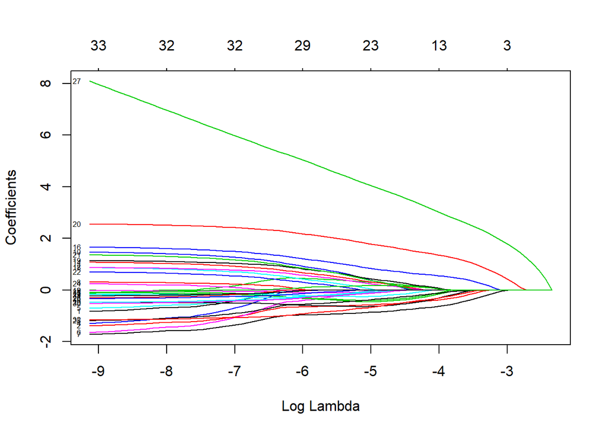

```r
trainX <- model.matrix(delay~.,data=data_train)[,-1]
trainY <- data_train$delay
set.seed(123)
lasso_model <- glmnet(x=trainX, y=trainY, alpha = 1, family="binomial")
plot(lasso_model, xvar="lambda", label = TRUE)
```

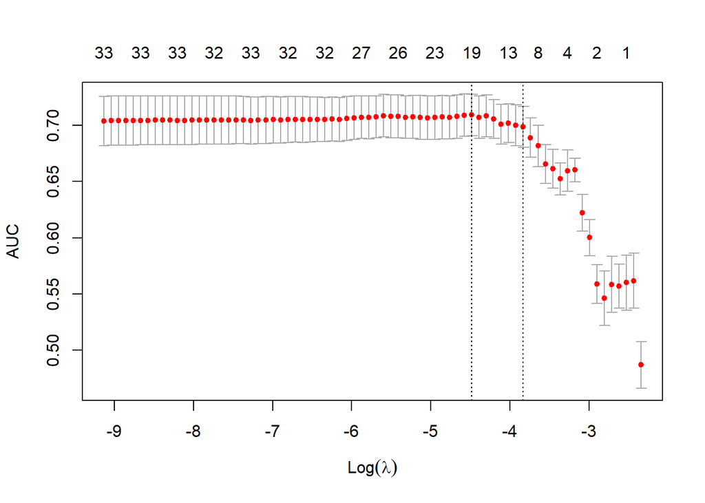

```r
set.seed(123)
cv_lasso <- cv.glmnet(x = trainX, y = trainY, alpha = 1, family = "binomial",
                      type.measure = "auc", nfolds = 10)
plot(cv_lasso)
```

```r
cv_lasso$nzero
```

```
##  s0  s1  s2  s3  s4  s5  s6  s7  s8  s9 s10 s11 s12 s13 s14 s15 s16 s17 s18 s19
##   0   1   1   1   1   2   2   2   3   4   4   5   7   8   8   9  10  13  13  13
## s20 s21 s22 s23 s24 s25 s26 s27 s28 s29 s30 s31 s32 s33 s34 s35 s36 s37 s38 s39
##  15  16  17  19  19  20  21  21  23  23  24  26  26  26  26  26  26  27  27  29
## s40 s41 s42 s43 s44 s45 s46 s47 s48 s49 s50 s51 s52 s53 s54 s55 s56 s57 s58 s59
##  29  29  30  32  32  32  33  32  32  32  32  32  32  33  33  33  33  32  32  32
## s60 s61 s62 s63 s64 s65 s66 s67 s68 s69 s70 s71 s72 s73
##  32  32  33  33  33  33  33  33  33  33  33  33  33  33
```

```r
lambda <- cv_lasso$lambda[21]
```

15개의 변수를 포함하는 모델은 **21번째** 모델이다.

### 8.1 모델에 어떠한 변수들이 포함되었는가?

```r
coef(cv_lasso, s=lambda)
```

```
## 34 x 1 sparse Matrix of class "dgCMatrix"
##                        1
## (Intercept) -1.278293217
## carrierDH    .
## carrierDL   -0.428662456
## carrierMQ    0.123884445
## carrierOH    .
## carrierRU    .
## carrierUA    .
## carrierUS   -0.689982217
## deptime7     .
## deptime8    -0.267010268
## deptime9     .
## deptime10   -0.036376898
## deptime11    .
## deptime12   -0.418670477
## deptime13    0.002062416
## deptime14   -0.210090398
## deptime15    0.597382215
## deptime16    .
## deptime17    .
## deptime18    0.143418519
## deptime19    1.440262474
## deptime20    .
## deptime21    .
## destJFK      .
## destLGA      .
## originDCA   -0.174373252
## originIAD    .
## weather1     3.237216921
## dayweek2     .
## dayweek3     .
## dayweek4     .
## dayweek5     .
## dayweek6    -0.382526186
## dayweek7     0.099324451
```

21번째 모델에는 **carrierMQ, carrierDL, carrierUS, deptime8, deptime10, deptime12, deptime13, deptime14, deptime15, deptime18, deptime19, originDCA, weather1, dayweek6, dayweek7** 변수가 포함된다.

### 8.2 Threshold 일때 test set에 대한 confusion matrix를 계산해 보자.

```r
set.seed(123)
pred_prob <- predict(cv_lasso, newx = model.matrix(delay~., data = data_test)[,-1], s = lambda, type = "response")

pred_class <- predict(cv_lasso, newx = model.matrix(delay~., data = data_test)[,-1], s = lambda, type = "class")

confusionMatrix(factor(pred_class, levels = c("ontime", "delayed")), data_test$delay, positive = "delayed")
```

```
## Confusion Matrix and Statistics
##
##           Reference
## Prediction ontime delayed
##    ontime     523     103
##    delayed      2      19
##
##                Accuracy : 0.8377
##                  95% CI : (0.807, 0.8653)
##     No Information Rate : 0.8114
##     P-Value [Acc > NIR] : 0.04666
##
##                   Kappa : 0.2227
##
##  Mcnemar's Test P-Value : < 2e-16
##
##             Sensitivity : 0.15574
##             Specificity : 0.99619
##          Pos Pred Value : 0.90476
##          Neg Pred Value : 0.83546
##              Prevalence : 0.18856
##          Detection Rate : 0.02937
##    Detection Prevalence : 0.03246
##       Balanced Accuracy : 0.57596
##
##        'Positive' Class : delayed
##
```

Lasso regression을 적용한 결과, k = 0.5일때 표와 같은 결과가 나온다.

### 9. 6, 7, 8번에서 수립한 logistic regression model들에 대해서, test set에 대한 성능을 나타내는 ROC Curve 를 하나의 그래프로 시각화하고, AUC값을 비교해 보자.

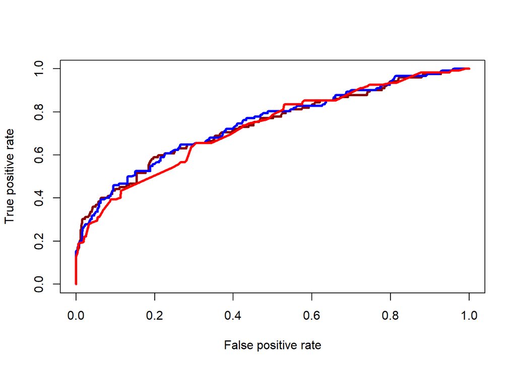

```r
library(ROCR)
set.seed(123)
pred6 = prediction(prob_test, data_test$delay, c("ontime","delayed"))
perf6 = performance(pred6, measure = "tpr", x.measure = "fpr")

pred7 = prediction(cof_prob1, data_test$delay, c("ontime","delayed"))
perf7 = performance(pred7, measure = "tpr", x.measure = "fpr")

pred8 = prediction(pred_prob, data_test$delay, c("ontime","delayed"))
perf8 = performance(pred8, measure = "tpr", x.measure = "fpr")

plot(perf6, col="darkred", lwd =3)
plot(perf7, col="blue", lwd = 3, add=TRUE)
plot(perf8, col="red", lwd = 3, add=TRUE)
```

```r
auc6 = performance(pred6, measure = "auc")
auc6@y.values[[1]]
```

```
## [1] 0.7388681
```

```r
auc7 = performance(pred7, measure = "auc")
auc7@y.values[[1]]
```

```
## [1] 0.7445355
```

```r
auc8 = performance(pred8, measure = "auc")
auc8@y.values[[1]]
```

```
## [1] 0.7284153
```

backward selection을 사용한 7번 모델이 가장 auc가 높긴하지만, 큰 차이는 나지 않는다.

### 10. Training set을 대상으로 k-nn을 적용해보자. 이때 train() 함수를 사용한 cross validation으로 Accuracy 가 가장 높은 best 값을 찾는다.

```r
library(caret)
z_normalized <- c("center", "scale")
tune_grid <- expand.grid(k=seq(1,99,2))
cv <- trainControl(method = "repeatedcv", number = 5, repeats = 5)
set.seed(123)
knn_fit <- train(data=data_train, delay~., method = "knn", trControl = cv, preProcess = z_normalized, tuneGrid = tune_grid)
knn_fit
```

```
## k-Nearest Neighbors
##
## 1512 samples
##    6 predictor
##    2 classes: 'ontime', 'delayed'
##
## Pre-processing: centered (33), scaled (33)
## Resampling: Cross-Validated (5 fold, repeated 5 times)
## Summary of sample sizes: 1210, 1210, 1209, 1210, 1209, 1210, ...
## Resampling results across tuning parameters:
##
##   k   Accuracy   Kappa
##    1  0.7841283  0.258302431
##    3  0.8132271  0.278356016
##    5  0.8308159  0.296756436
```

[output cut: 50 more lines]

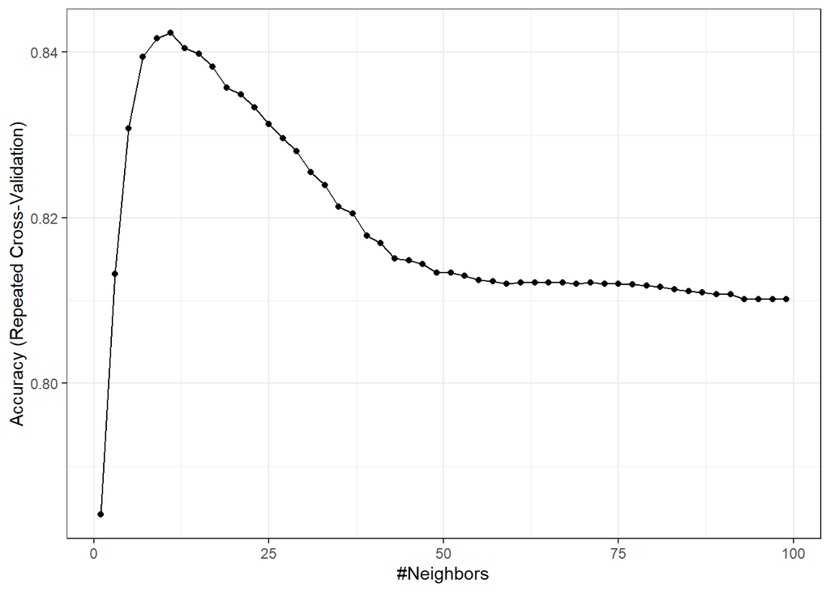

```r
library(ggplot2)
ggplot(knn_fit) + theme_bw()
```

k값에 따라 시각화한 그래프

### 10.1 best 값은 얼마인가?

```r
knn_fit$bestTune
```

```
##    k
## 6 11
```

```r
knn_fit$results[2]$Accuracy[6]
```

```
## [1] 0.8423268
```

### 10.2 Test set에 대한 confusion matrix를 계산해 보자. 그리고 Test set에 대한 성능을 앞서 수립한 logistic regression model들과 비교해보자.

```r
final_pred = predict(knn_fit, data_test)
confusionMatrix(data_test$delay, final_pred, positive = "delayed")
```

```
## Confusion Matrix and Statistics
##
##           Reference
## Prediction ontime delayed
##    ontime     520       5
##    delayed     88      34
##
##                Accuracy : 0.8563
##                  95% CI : (0.8268, 0.8824)
##     No Information Rate : 0.9397
##     P-Value [Acc > NIR] : 1
##
##                   Kappa : 0.3643
##
##  Mcnemar's Test P-Value : <2e-16
##
##             Sensitivity : 0.87179
##             Specificity : 0.85526
##          Pos Pred Value : 0.27869
##          Neg Pred Value : 0.99048
##              Prevalence : 0.06028
##          Detection Rate : 0.05255
##    Detection Prevalence : 0.18856
##       Balanced Accuracy : 0.86353
##
##        'Positive' Class : delayed
##
```

accuracy가 **0.8563**으로, 앞서 적용한 6, 7, 8번 모델에 비해 성능이 뛰어난 것을 알 수 있다.